# ATELIER 6 : URBANISATION

Auteur·rice

DIEME Alida Gwladys, KONE Vassamouka,KOUAKOU Adjoua Sylvie

Date de publication

2025-05-27

> Exemple de traitement réalisé par les groupes d’auditeur à partir de l’enquête AfroMapR.

# 1. Préparation des données

## Choix des variables à analyser

Ces variables ne concernent pas l’urbanisation, mais la variable choisie par le groupe (lieu de résidence personnes : Bouaké, reste du pays, étranger) s’est révélée trop peu discriminante pour une analyse statistique puisque 90% des personnes interrogées résidaient à Bouaké. Faute de temps pour coder les quartiers de Bouaké, l’analyse s’est portée sur la question du choix des personnes interrogées.

## Recodage éventuel des étiquettes

On peut raccourcir ou modifier les étiquettes pour faciliter leur affichage ou fusionner des modalités trop peu nombreuses. Ici on a décidé de retirer les enquêtes effectuées par les formateurs pour ne garder que celles réalisées par les sept groupes d’ateliers.

# 2. Analyse de la variable à expliquer Y

## Fréquence simple

| Modalité | Fréquence |
| --- | --- |
| Femme | 20 |
| Homme | 86 |
| Sum | 106 |

## Pourcentage

| Modalité | % |
| --- | --- |
| Femme | 18.9 |
| Homme | 81.1 |
| Sum | 100.0 |

## Diagramme en bâtons

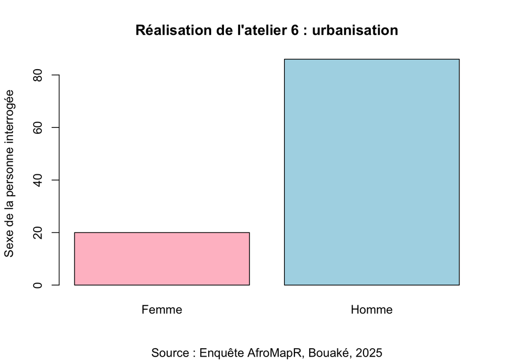

# 3. Analyse de la variable explicative X

## Fréquence simple

| Modalité | Fréquence |
| --- | --- |
| Agri. | 11 |
| Demo. | 11 |
| Eau | 17 |
| Mines | 11 |
| Santé | 14 |
| Urba. | 17 |
| Trans. | 21 |
| Sum | 102 |

## Pourcentage

| Modalité | % |
| --- | --- |
| Agri. | 10.8 |
| Demo. | 10.8 |
| Eau | 16.7 |
| Mines | 10.8 |
| Santé | 13.7 |
| Urba. | 16.7 |
| Trans. | 20.6 |
| Sum | 100.0 |

## Diagramme en bâtons

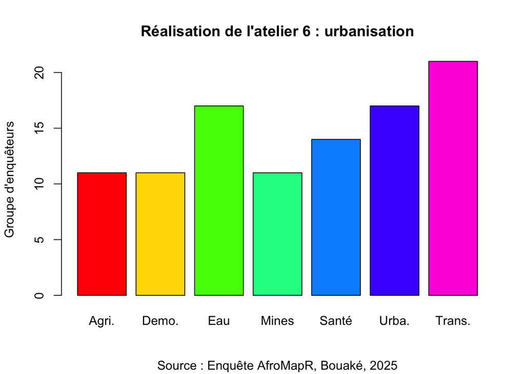

# 4. Relation entre X et Y

## Hypothèses

On veut tester l’existence d’une relation entre les deux variables précédentes.

- **H0** : Il n’y a pas de relation entre X et Y
- **H1** : Il y a une relation entre X et Y
- **Justification de l’hypothèse H1** : On suppose que les groupes d’enquêteurs comportant plus de femmes ont interrogé également plus de femmes. Et inversement pour les groupes d’enquêteurs ayant plus d’hommes.

## Tableau de contingence

|  | Femme | Homme | Sum |
| --- | --- | --- | --- |
| Agri. | 6 | 5 | 11 |
| Demo. | 2 | 9 | 11 |
| Eau | 2 | 15 | 17 |
| Mines | 1 | 10 | 11 |
| Santé | 3 | 11 | 14 |
| Urba. | 2 | 15 | 17 |
| Trans. | 4 | 17 | 21 |
| Sum | 20 | 82 | 102 |

## Pourcentage en ligne

|  | Femme | Homme | Sum |
| --- | --- | --- | --- |
| Agri. | 54.5 | 45.5 | 100 |
| Demo. | 18.2 | 81.8 | 100 |
| Eau | 11.8 | 88.2 | 100 |
| Mines | 9.1 | 90.9 | 100 |
| Santé | 21.4 | 78.6 | 100 |
| Urba. | 11.8 | 88.2 | 100 |
| Trans. | 19.0 | 81.0 | 100 |
| Sum | 19.6 | 80.4 | 100 |

On constate une forte singularité du groupe 1 (agriculture) qui est le seul à avoir interrogé majoritairement des femmes.

## Graphique en mosaïque

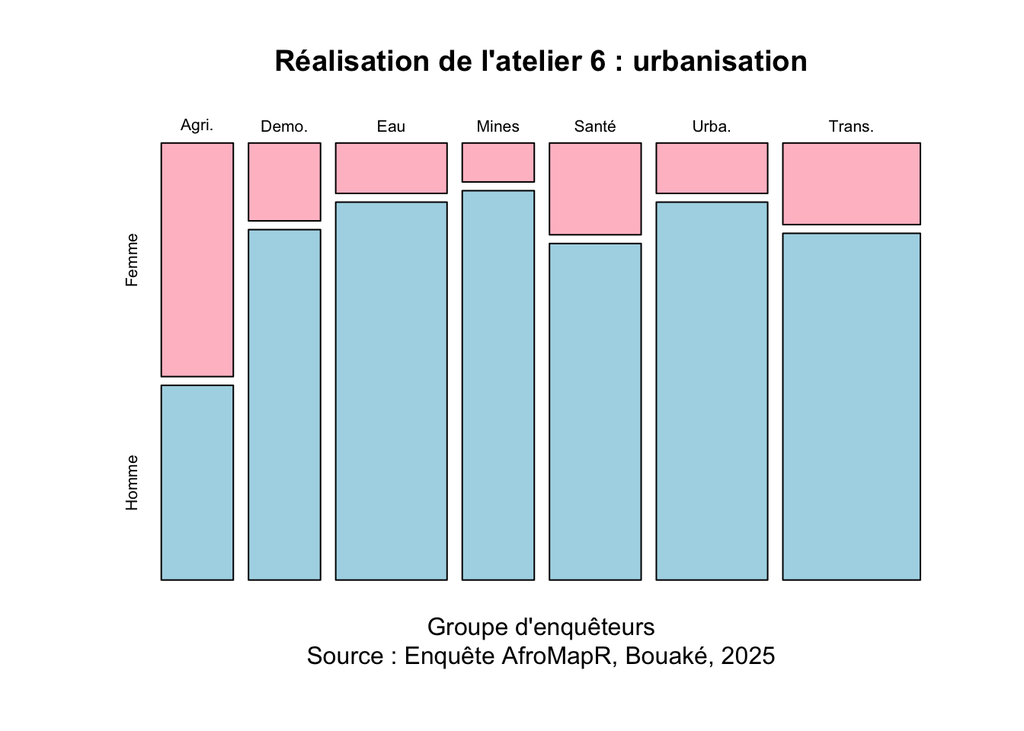

## Test du chi-2

On part de l’hypothèse nulle H0 : il n’y a pas de relation entre X et Y. Les variations en Y en fonction de X sont l’effet du hasard.

On effectue un test du chi-2 qui donne les résultats suivants :

```
    Pearson's Chi-squared test

data:  tabcont
X-squared = 10.664, df = 6, p-value = 0.09932
```

## Conclusion

Pour que le test du chi-2 soit pleinement valable, il faudrait soit accroître la taille de l’échantillon, soit procéder à des regroupements des variables en catégories moins nombreuses, par exemple en isolant le groupe 1, agriculture contre tous les autres.